# STSCI 5030 - Fall 2018 - HW1 Q2

Harry Lu, dl947

Due Friday, September 14, 2018

# Read data

```r
brain_data=read.table("Download/BrainWeight.txt",header=TRUE)
#colnames(brain_data)=c("B","W","G")
brain_data$ln_B=log(brain_data$Brain,base=exp(1))
brain_data$ln_W=log(brain_data$Body,base=exp(1))
brain_data$ln_G=log(brain_data$Gestation,base=exp(1))
```

# a

> Use the `pairs` function to construct a scatterplot matrix of the logarithms of B, W, G.

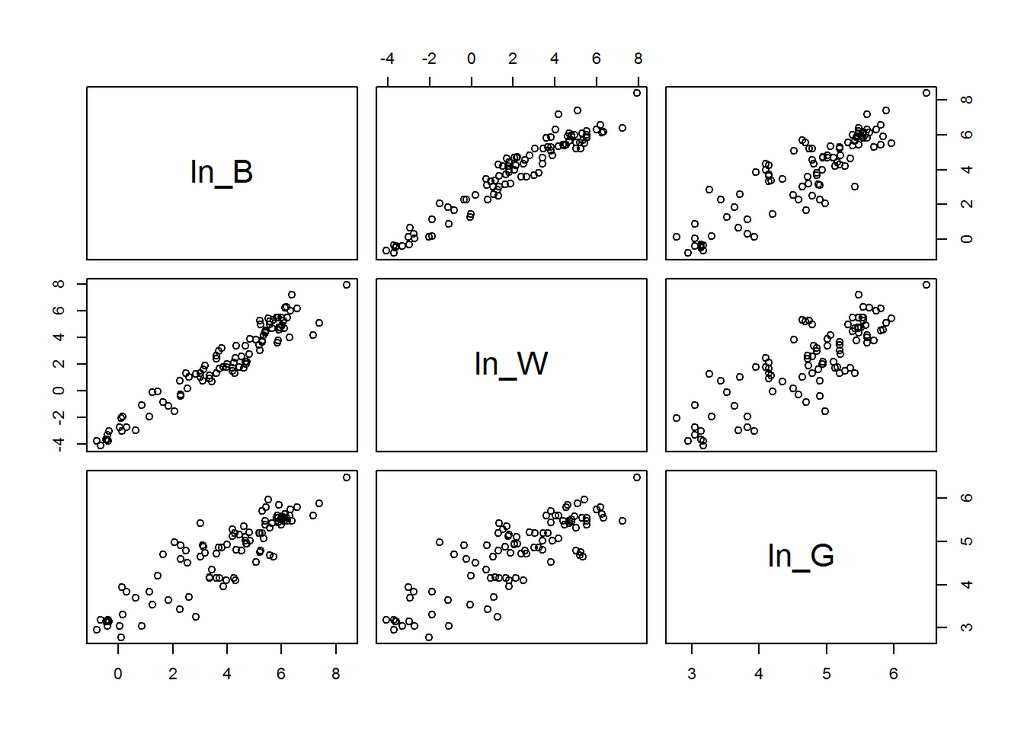

```r
pairs(brain_data[,4:6])
```

# b

> Use the `cor` function to determine the correlation matrix for the three (logged) variables.

```r
cor(brain_data[,4:6])
```

```
##           ln_B      ln_W      ln_G
## ln_B 1.0000000 0.9642905 0.8912940
## ln_W 0.9642905 1.0000000 0.8455317
## ln_G 0.8912940 0.8455317 1.0000000
```

# c

> Use the `lm` function in R to fit the MLR model,
> $$\ln B = \beta_0 + \beta_1\ln W + \beta_2\ln G + e$$
> and print out the `summary` of the model fit.

```r
l=lm(brain_data$ln_B~brain_data$ln_W+brain_data$ln_G)
summary(l)
```

```
##
## Call:
## lm(formula = brain_data$ln_B ~ brain_data$ln_W + brain_data$ln_G)
##
## Residuals:
##      Min       1Q   Median       3Q      Max
## -1.00286 -0.30372 -0.05242  0.37851  1.58788
##
## Coefficients:
##                 Estimate Std. Error t value Pr(>|t|)
## (Intercept)     -0.45728    0.45848  -0.997    0.321
## brain_data$ln_W  0.55117    0.03236  17.033   <2e-16 ***
## brain_data$ln_G  0.66782    0.10875   6.141    2e-08 ***
## ---
## Signif. codes:  0 '***' 0.001 '**' 0.01 '*' 0.05 '.' 0.1 ' ' 1
##
## Residual standard error: 0.4902 on 93 degrees of freedom
## Multiple R-squared:  0.9501, Adjusted R-squared:  0.949
## F-statistic: 885.2 on 2 and 93 DF,  p-value: < 2.2e-16
```

```r
#plot(l)
```

# d

> Create the design/covariate matrix, $X$, for the model in **c** and verify that the coefficient estimates in the summary ouput are given by the least squares formula: $(X^TX)^{-1}X^Ty$.

```r
cov_mat=matrix(data=1,nrow=96,ncol=3)
cov_mat[,2]=brain_data[,5]
cov_mat[,3]=brain_data[,6]
y_mat=matrix(data=0,nrow=96,ncol=1)
y_mat[,1]=brain_data[,4]
verify_mat=solve(t(cov_mat)%*%cov_mat)%*%t(cov_mat)%*%y_mat
l$coefficients
```

```
##     (Intercept) brain_data$ln_W brain_data$ln_G
##      -0.4572826       0.5511654       0.6678215
```

```r
verify_mat
```

```
##            [,1]
## [1,] -0.4572826
## [2,]  0.5511654
## [3,]  0.6678215
```

# e

> Obtain the fitted values for your model. Determine the squared correlation between the fitted values and the response vector. What value in the summary output does this number correspond to?

```r
l$coefficients
```

```
##     (Intercept) brain_data$ln_W brain_data$ln_G
##      -0.4572826       0.5511654       0.6678215
```

Squared correlation is also known as r-square, we can obtain it from the summary of the linear model:

```r
summary(l)$`r.squared`
```

```
## [1] 0.9500939
```

```r
summary(l)$`adj.r.squared`
```

```
## [1] 0.9490206
```

# f

> Compute the mean squared error and its square root using the residual vector from **e**. What value in the summary output is equal to the root mean squared error?

```r
l_res=summary(l)$residuals
mean(l_res^2)
```

```
## [1] 0.2327974
```

```r
sqrt(mean(l_res^2))
```

```
## [1] 0.4824908
```

# g

> Extract the residual vector (WG say) from the SLR model with y=ln(W) and x=ln(G). Rerun the MLR in **c** with ln(W) replaced by WG. Show that you get the same fitted values. What happens to the coefficients?

```r
l_WG=lm(brain_data$ln_W~brain_data$ln_G)
l_WG_res=summary(l_WG)$residuals  #WG is l_WG_res
l_new=lm(brain_data$ln_B~l_WG_res+brain_data$ln_G)
l$coefficients[2]
```

```
## brain_data$ln_W
##       0.5511654
```

```r
l_new$coefficients[2]
```

```
##  l_WG_res
## 0.5511654
```

The W term in the original model has the same value as the WG term in the new model. They have the same value because they also have the variable W. The other term (variable G)’s coefficients are different, but the new G’s coefficient is a linear combination of W/WG’s coefficient and the old G’s coefficient.

# h

> Extract the residuals (BG say) from SLR fit with y=ln(B) and x=ln(G). Construct a scatterplot of BG versus WG and add the regression line.

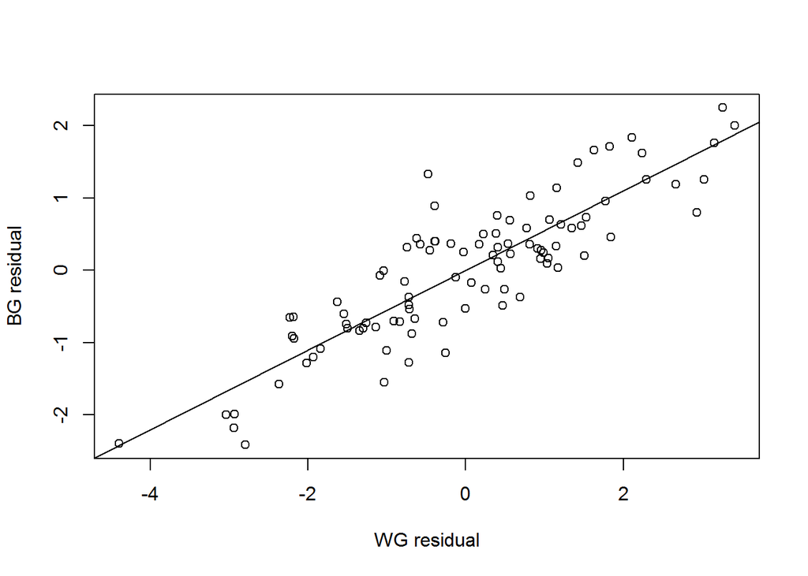

```r
l_BG=lm(brain_data$ln_B~brain_data$ln_G)
l_BG_res=summary(l_BG)$residuals

plot(l_BG_res~l_WG_res,ylab="BG residual",xlab="WG residual")
BGWG=lm(l_BG_res~l_WG_res)
abline(BGWG$coefficients[1],BGWG$coefficients[2])
```

# i

> Compare the slope of the regression of BG on WG to the estimated regression coefficients from the MLR in **c**.

```r
BGWG$coefficients
```

```
##  (Intercept)     l_WG_res
## 1.802422e-17 5.511654e-01
```

```r
l$coefficients
```

```
##     (Intercept) brain_data$ln_W brain_data$ln_G
##      -0.4572826       0.5511654       0.6678215
```